# Project: Investigate TMDb movie dataset

- Introduction
- Data Wrangling
- Exploratory Data Analysis
- Conclusions

## Introduction

The data set i have choosen for analysis is "TMDb movie data".This data set contains information about 10,000 movies collected from The Movie Database (TMDb), including user ratings and revenue.

# ##Questions:

# The questions i have choosen to study in this data set are:

## 1.Which genres are most popular from year to year?

## 2.What kinds of properties are associated with movies that have high revenues?

```python
# Use this cell to set up import statements for all of the packages that you
#   plan to use.
# Remember to include a 'magic word' so that your visualizations are plotted
# inline with the notebook. See this page for more:
# http://ipython.readthedocs.io/en/stable/interactive/magics.html
#importing numpy
import numpy as np
#importing pandas
import pandas as pd
#importing matplotlib
% matplotlib inline
#Reading the uploaded dataset
df = pd.read_csv('tmdb-movies.csv')
```

## Data Wrangling:

### Data Cleaning:

### In the cells below i am removing zeroes from budget and revenue columns to further use them in the analysis:

### Function to give the zero count from the columns:

```python
#Function to get number of zeroes
#Counting number of zeroes in budget
def CountZero(x,y):
    print(y.groupby(x).size())
```

### Counting number of zeroes in budget column:

```python
#Counting number of zeroes in budget column
CountZero("budget",df)
```

```
budget
0            5696
1               4
2               1
3               3
5               1
6               1
8               3
10              6
11              1
12              2
14              1
15              2
17              1
18              2
```

[output cut: 48 more lines]

### Counting number of zeroes in revenue:

```python
#Counting number of zeroes in revenue
CountZero("revenue",df)
```

```
revenue
0             6016
2                2
3                3
5                2
6                2
9                2
10               1
11               3
12               1
13               2
15               3
16               3
20               1
23               1
```

[output cut: 48 more lines]

### Filtering out the rows with zeroes and assigning it to a new dataframe:

```python
#Filtering out the rows with zeroes and assigning it to a new dataframe
df2 =  df[df!=0]
```

### testing the budget whether it has zeroes or not:

```python
#testing the budget whether it has zeroes or not.
CountZero("budget",df2)
```

```
budget
1.0             4
2.0             1
3.0             3
5.0             1
6.0             1
8.0             3
10.0            6
11.0            1
12.0            2
14.0            1
15.0            2
17.0            1
18.0            2
20.0            1
21.0            1
25.0            2
27.0            1
28.0            1
30.0            3
32.0            1
68.0            1
75.0            1
80.0            1
89.0            1
90.0            1
93.0            1
95.0            1
97.0            1
108.0           1
110.0           1
               ..
155000000.0     3
160000000.0    10
163000000.0     1
165000000.0     6
170000000.0     8
175000000.0     9
176000003.0     1
178000000.0     1
```

[output cut: 8 more lines]

```
215000000.0     1
220000000.0     1
225000000.0     3
237000000.0     1
245000000.0     1
250000000.0     7
255000000.0     1
258000000.0     1
260000000.0     2
270000000.0     1
280000000.0     1
300000000.0     1
380000000.0     1
425000000.0     1
Length: 556, dtype: int64
```

### testing the revenue whether it has zeroes or not:

```python
#testing the revenue whether it has zeroes or not.
CountZero('revenue',df2)
```

```
revenue
2.000000e+00    2
3.000000e+00    3
5.000000e+00    2
6.000000e+00    2
9.000000e+00    2
1.000000e+01    1
1.100000e+01    3
1.200000e+01    1
1.300000e+01    2
1.500000e+01    3
1.600000e+01    3
2.000000e+01    1
2.300000e+01    1
2.700000e+01    1
2.900000e+01    1
3.000000e+01    1
3.200000e+01    2
4.200000e+01    1
4.300000e+01    1
4.600000e+01    1
7.800000e+01    1
8.000000e+01    1
9.700000e+01    1
1.000000e+02    1
1.220000e+02    1
1.250000e+02    1
1.340000e+02    1
1.440000e+02    1
1.930000e+02    1
2.000000e+02    1
               ..
9.339592e+08    1
9.382127e+08    1
9.543059e+08    1
9.551198e+08    1
9.584000e+08    1
9.610000e+08    1
9.707619e+08    1
9.764756e+08    1
```

[output cut: 8 more lines]

```
1.108561e+09    1
1.118889e+09    1
1.123747e+09    1
1.156731e+09    1
1.215440e+09    1
1.274219e+09    1
1.327818e+09    1
1.405036e+09    1
1.506249e+09    1
1.513529e+09    1
1.519558e+09    1
1.845034e+09    1
2.068178e+09    1
2.781506e+09    1
Length: 4701, dtype: int64
```

## Exploratory Data Analysis

# Question 1:Which genres are most popular from year to year?

### Using Groupby i have filtered out the popular genres from year to year as below:

```python
df1 = df2.groupby(['release_year'])['genres'].apply(lambda x: x.value_counts().index[0]).reset_index()
df1
```

|  | release_year | genres |
| --- | --- | --- |
| 0 | 1960 | Horror |
| 1 | 1961 | Horror |
| 2 | 1962 | Drama |
| 3 | 1963 | Horror |
| 4 | 1964 | Comedy\|Romance |
| 5 | 1965 | Drama |
| 6 | 1966 | Action\|Western |
| 7 | 1967 | Comedy\|Drama\|Romance |
| 8 | 1968 | Drama |
| 9 | 1969 | Drama |
| 10 | 1970 | Horror |
| 11 | 1971 | Drama |
| 12 | 1972 | Comedy |
| 13 | 1973 | Crime\|Drama |
| 14 | 1974 | Drama |
| 15 | 1975 | Drama |
| 16 | 1976 | Horror\|Thriller |
| 17 | 1977 | Horror\|Science Fiction |
| 18 | 1978 | Horror |
| 19 | 1979 | Comedy |
| 20 | 1980 | Action\|Comedy |
| 21 | 1981 | Comedy |
| 22 | 1982 | Comedy |
| 23 | 1983 | Comedy |
| 24 | 1984 | Comedy |
| 25 | 1985 | Drama |
| 26 | 1986 | Comedy |
| 27 | 1987 | Comedy |
| 28 | 1988 | Drama |
| 29 | 1989 | Comedy |
| 30 | 1990 | Comedy\|Drama |
| 31 | 1991 | Drama |
| 32 | 1992 | Drama |
| 33 | 1993 | Comedy |
| 34 | 1994 | Comedy |
| 35 | 1995 | Comedy |
| 36 | 1996 | Comedy |
| 37 | 1997 | Comedy |
| 38 | 1998 | Comedy\|Drama |
| 39 | 1999 | Comedy |
| 40 | 2000 | Comedy |
| 41 | 2001 | Comedy |
| 42 | 2002 | Comedy\|Drama |
| 43 | 2003 | Comedy |
| 44 | 2004 | Comedy |
| 45 | 2005 | Drama |
| 46 | 2006 | Drama |
| 47 | 2007 | Comedy |
| 48 | 2008 | Drama |
| 49 | 2009 | Comedy |
| 50 | 2010 | Drama |
| 51 | 2011 | Drama |
| 52 | 2012 | Drama |
| 53 | 2013 | Drama |
| 54 | 2014 | Drama |
| 55 | 2015 | Drama |

## The above table gives the popular genres from year to year starting from 1960-2015

# Question 2:What kinds of properties are associated with movies that have high revenues?

## In the cell below i am getting all the properties associated with movies that have high revenue:

[output not shown]

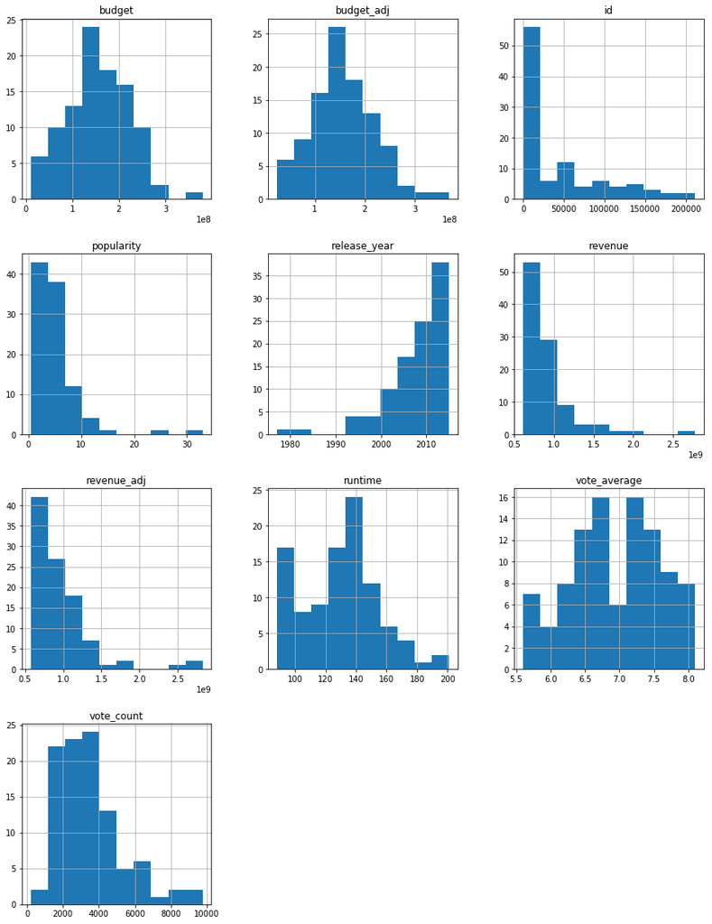

```python
df3 = df2.sort_values(by='revenue', ascending=False)
df4=df3.head(100)
df4.hist(figsize=(15,20))
```

# Question 3: Correlation between revenue and budget:

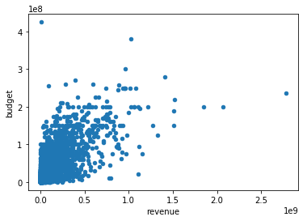

```python
df2.plot(kind='scatter',x='revenue',y='budget')
```

# Conclusions and limitations:

## Question 1:Which genres are most popular from year to year?

#### The table provides the most popular genre according to year using the groupby function of pandas

## Question 2:What kinds of properties are associated with movies that have high revenues?

## According to the histograms above,the points i can notice for movies with highest revenue are:

#### 5.Popularity is more towards 0-10 range for the movies

#### 6.Vote count is in between 1500-4000 for most movies

```python
from subprocess import call
call(['python', '-m', 'nbconvert', 'Investigate_a_Dataset.ipynb'])
```